# Project Report: Heart Attack Indicators 2023

#### 6.4.3 BMI

Firstly, I wanted to visualize the relationship between average BMI within states, so I plotted a chloropleth map of US States to see whether different states had different mean BMIs. If my hypothesis is wrong, we would see all states around the same shade of color.

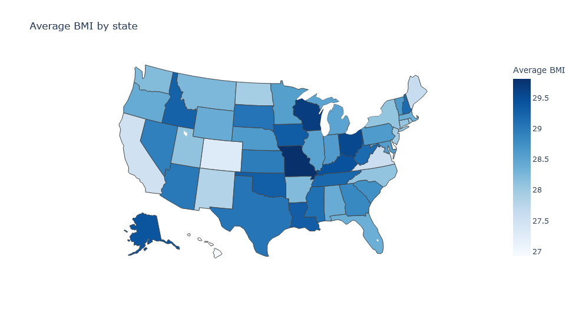

Nice! There is a different mean in each state. We know that any result we get from a dataset of nearly 450,000 observations will be statistically significant, but it would be wrong to not do our due diligence and run a one-way ANOVA test at a significance level of $a = 0.05$ to confirm the different means in each state.

```
The F statistic is: 73.60617044156776
The p-value is: 0.0
```

As mentioned previously, the enormous amount of data in the dataset means that the p-value will be incredibly small, so small in this case that (I did research to make sure this was the case) scipy outputs a value of 0.0 instead of the actual value because it is so small.

I ended up imputing all the missing BMI values based on state means.

I then went on to graph a histogram of BMI with a hue of heart attacks so that I could see the difference, if any, in BMI means in people who have had heart attacks and people who haven’t had heart attacks.

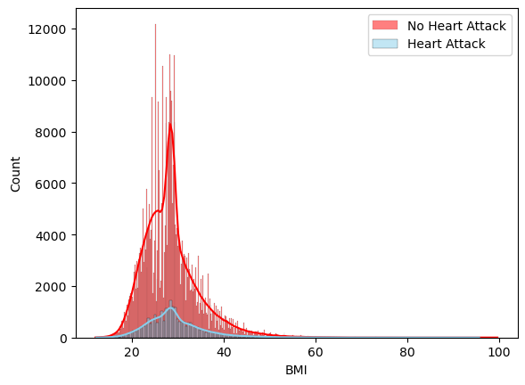

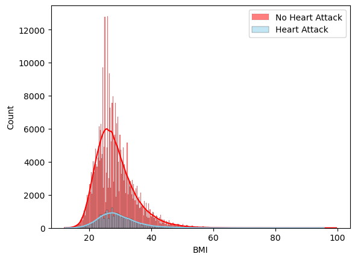

Looks much smoother. Interesting caveat to imputing values by another variable’s mean. It is now clear that the heart attack histogram’s mean is slightly above the non-heart attack mean.

I wanted to ensure that what I was seeing was what was happening in the data, so I ran a difference in mean hypothesis test with significance level $a=0.05$ to confirm my results:

```
The p-value is 1.69e-79
The difference in BMI means is 0.8399708138100266
```

As expected, the p-value is very low and the difference in means is just above 0.8 BMI units, indicating a relationship between higher BMI and heart attack likelihood. I wanted to look deeper into this relationship, so I decided to bin BMI into quartiles and see heart attack proportions in each quartile.

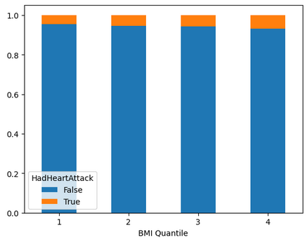

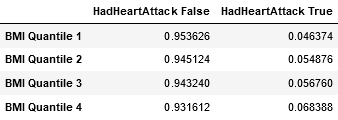

The heart attack proportion does increase as you move up the BMI quantiles, with individuals in the top 25% of BMIs being 47% more likely to get a heart attack as compared to individuals in the bottom 25%.

I then wanted to see whether heart attack likelihood and state were linked. I assumed they would be, as we have just proved that heart attacks and BMI are linked, and BMI and states are linked. I plotted a similar chloropleth but this time with heart attack proportions in each state.

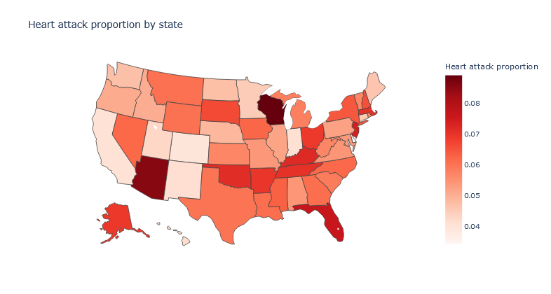

Indeed, there are definitely different proportions in each state. I noticed that the states that were lighter before (in BMI means) were still light, and same for darker states too. I wanted to further visualize this relationship through a scatterplot where each point is a state.

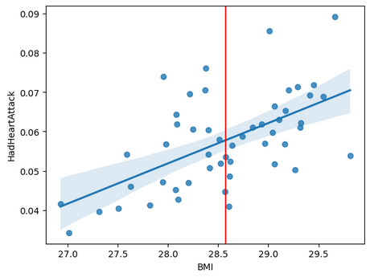

Interestingly, there is a correlation in average state BMI (the x-axis) and proportion of heart attacks in the state (y-axis), with the median BMI in the dataset as the vertical red line. This means that state governments might have the ability to impact heart attack risk in their own state if they aim at decreasing their average BMI.

To further this exploration, I wanted to separate the US into regions and see the hues on the scatterplot to understand whether regional cultures are correlated, as I understand that US cuisines and lifestyles are separated by region rather than just states.

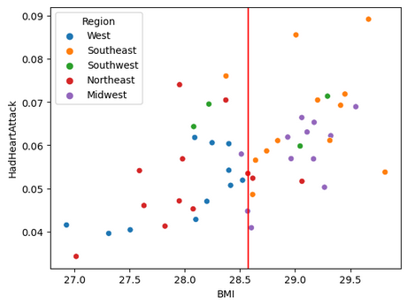

It does seem like states in the West tend to be on the lower left of the median, while Midwestern and Southeastern states are on the upper right of the median line. This could further support my hypothesis of cultures and cuisines in states being a factor for average BMI, and further, heart attack risk.

#### 6.4.4 Vaccination Statuses

The main intention behind investigating vaccination statuses and heart attack risk is to see whether anti-vaxxers hold any weight in their arguments. I started by plotting the proportions of each vaccine in the dataset to coarsely see any relationship. If there is no relationship, we hope to see that the proportions are even.

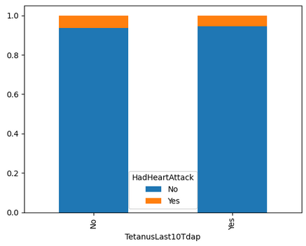

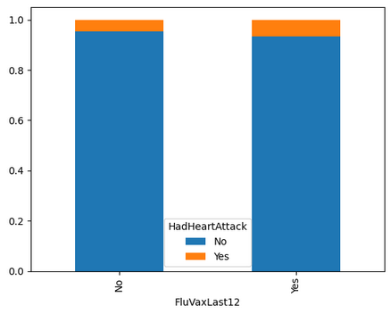

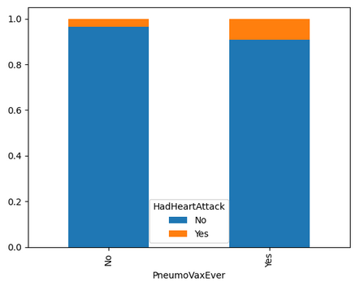

We see that for the Tetanus vaccine, the proportions are essentially the same, but what about the flu vaccine and the pneumo vaccine! Are anti-vaxxers right all along? I was worried about this predicament, until I had an idea to see the distribution for ages for both flu and pneumo vaccines to see which individuals are taking these vaccines. As was asserted in question 1, older individuals tend to have higher rates of heart attacks.

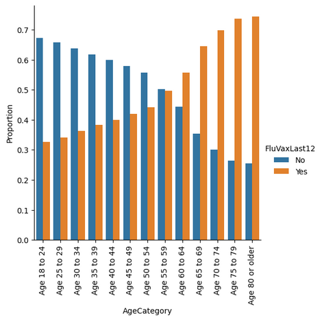

This is the proportion distribution by ages, with the proportion of the age bin on the y-axis and the age bins on the x-axis. This graph makes sense, as we see older people tend to take the flu vax more often (last12 indicating the vaccine was taken in the last 12 months). Now let’s visualize the pneumo vaccine:

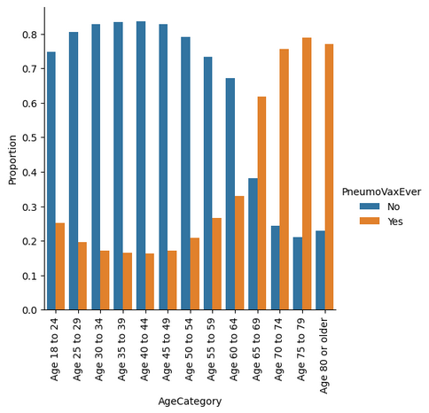

That makes sense too! I noticed an interesting dip that bottoms out at around age 35-39, but that is probably a result of changing government vaccine recommendations over time.

Finally, to prove those anti-vaxxers wrong (at least, for the pneumococcus and flu vaccines), let’s visualize the proportions while controlling for age:

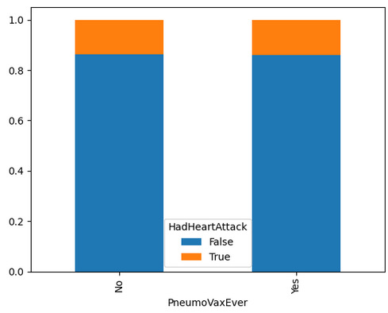

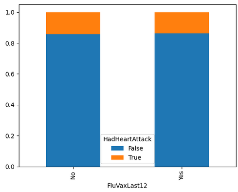

Both of these graphs were only analyzing the oldest age bin of 80 or over, which have the highest rate of heart attacks out of all the age bins. Perfect! We don’t need to worry about anti-vaxxers being right anymore.

#### 6.4.5 Underlying Conditions

Finally, I wanted to look at underlying conditions to see which particular conditions have effects on heart attack likelihoods. For the sake of saving space, I will only print out the cross tables for Angina and Diabetes as those conditions are obvious in the way that they affect the heart, and have significant differences in proportions (specifically, individuals with Angina are 15.6 times more likely to suffer a heart attack than individuals without!).

|  | HadHeartAttack False | HadHeartAttack True |
| --- | --- | --- |
| **HadAngina No** | 0.971140 | 0.028860 |
| **HadAngina Yes** | 0.549902 | 0.450098 |

|  | HadHeartAttack False | HadHeartAttack True |
| --- | --- | --- |
| **HadDiabetes No** | 0.957893 | 0.042107 |
| **Pre-diabetes or borderline diabetes** | 0.922812 | 0.077188 |
| **HadDiabetes Yes** | 0.857297 | 0.142703 |
| **Pregnancy Diabetes** | 0.971003 | 0.028997 |

I wanted to look at depressive disorders and their effect on heart attacks. I plotted the proportion graph like in the vaccine section:

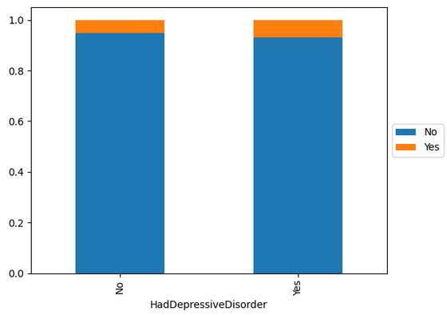

Indeed, individuals with depressive disorders are actually 32% more likely to suffer from heart attacks. I was curious how depressive disorders link to age, so I plotted the binned proportions:

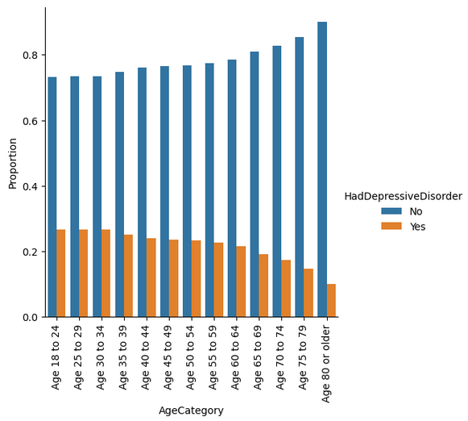

We find that this relationship has the reverse trend of the vaccine status one, probably because those who are diligent about their health take more vaccines and are less likely to have heart attacks because of their diligence, while those with depressive disorders may die off sooner. The implications to this trend is that if we do control for age, the likelihood of heart attack is likely to be greater than 32%, it is biased the opposite way of the vaccine trend.

## 7 Recommendations to stakeholder(s)

#### 7.0.1 Demographic Recommendations

Organizations like the CDC and Mayo Clinic should gather more demographically representative data. The dataset provided consisted primarily of white individuals. With a less biased dataset, we can draw conclusions with more confidence.

The distribution of healthcare resources should prioritize areas with a higher prevalence of heart attack risks. There is a notable variation in heart attack risk based on race and ethnicity, with multiracial and white individuals being 1.5 times more likely than Hispanic individuals to experience heart attacks. Allocating resources to neighborhoods with higher concentrations of affected racial groups can enhance the preparedness of individual hospitals for emergencies, ultimately leading to a reduction in deaths.

#### 7.0.2 Access Recommendations

I recommend that state and national governments strive to provide increased access to routine checkups for Hispanic , multiracial, and other race groups. This effort aims to reduce the 7-15% gap in healthcare access through more services, lower costs, and better coverage. Enhancing coverage and reducing the general costs of checkups will make them more accessible for these groups, as cost is likely a contributing factor. Further investigation into the reasons why these groups have fewer checkups is also warranted. The growing use of telehealth, which enables doctors to provide treatment remotely, can offer greater convenience and reduce costs, potentially increasing the frequency of checkups.

Additionally, I suggest that the healthcare sector should work on improving its public image and building greater trust and appreciation among people. My analysis suggests that this could be a factor in the persistent gap, due to cultural and regional differences in education and attitudes towards healthcare services. In terms of education, organizing community speakers at local events and in schools could enhance understanding of healthcare services and their importance. Hosting community-building events like cookouts, fairs, game nights, and parties may also help people feel more connected and comfortable with healthcare in their area.

#### 7.0.3 Lifestyle Recommendations

- Lifestyle habits that individuals should follow, doctors should recommend, and public heath officials should survey and promote (in the order of most important to least) are:
  - Not Smoking
    - This is the largest factor to preventing heart disease that is not stressed enough in public health. For example, the Mayo Clinic’s “Heart Disease Risk Calculator” does not ask about smoking.<sup>2</sup>
  - Engaging in physical activity
  - Drinking alcohol in moderation
  - Sleeping for longer hours
    - On average across all age categories, individuals who had a heart attack got 0.405 less hours of sleep than those who did not have a heart attack.
    - Sleep is much more important for reducing your change for heart disease the younger you are.
  - Not using E-Cigarettes
    - If you are going to smoke these are a better alternative as there is much less risk of heart attack associated with them.
- These recommendations are limited based on the fact the correlation does not mean causation. In addition, these reccommendations were based off a sample which may not be representative of everyone. However, these are still important lifestyle decisions that will likily reduce an individuals risk of heart attack.
- While I was able to rank the importance of each lifestyle habit, I was not able to individually quantify how much of each lifestyle decision one should engage in to reduce their risk of heart attack. This is due to the lack of continuous variables in the data set. Stakeholders should attempt to survey this data if they wish to know more.

#### 7.0.4 Underlying Conditions and BMI Recommendations

- BMI: individuals in the top 25% of BMIs being 47% more likely to get a heart attack as compared to individuals in the bottom 25%.
  - Healthcare sectors and state governments in states with a higher average BMI need to promote healthier diets and lifestyles to prevent heart disease
    - Especially in Midwestern and Southeastern states, where average BMI and heart attack proportions are the highest
  - Individuals that are looking to immigrate to the US that may be genetically prone to heart attacks need to be aware of the different cuisines and cultures of each state and choose accordingly
  - The federal government needs to play a greater part in promoting healthier eating habits to reduce nation-wide BMI
- Vaccinations:
  - Anti-vaxxers have no backing to their claim, at least with respect to the pneumo vaccine and flu vaccine.
  - Individuals who feel iffy about taking vaccinations don’t have to worry about adverse health risks, at least with regards to heart attacks.
- Underlying Conditions: individuals with depressive disorders are actually 32% more likely to suffer from heart attacks
  - Individuals who have depressive disorders need to be wary about developing heart disease and heart attacks.
  - Medical sectors that deal with depressive disorders need to be proactive in stopping heart attacks in depressed individuals

## References

[1] Chase, Brandon. *More evidence moderate drinking is good for your heart. Also: a reason.* (Massachusetts: Harvard Gazette, 2023). https://news.harvard.edu/gazette/story/2023/06/is-drinking-in-moderation-good-for-your-heart/#:~:text=And%20when%20the%20investigators%20looked,cardiac%20effects%2C%E2%80%9D%20Tawakol%20said.

[2] Heart Disease Risk Calculator (Mayo Clinic Health System: 2023). https://www.mayoclinichealthsystem.org/locations/cannon-falls/services-and-treatments/cardiology/heart-disease-risk-calculator